# Biomedical Statistics Homework 05

- Show All Code
- Hide All Code
- View Source

Author

Zipeng YE (CEBSIT, CAS)

# 1 Question 1

## 1.1 手动计算 Pearson 和 Spearman 相关系数

### 1.1.1 数据读取

提取 `GAPDH` 和 `ACTB` 这两个管家基因在 12 个样本中的表达量。

```r
# 读取 TSV 文件（第一行是列名，第一列是基因名）
data <- read.table("data/raw/homework5-Q1.tsv",
                   header = TRUE, sep = "\t", row.names = 1)

# 提取 GAPDH 和 ACTB 的数据行并转换为数值型向量
gapdh <- as.numeric(data["GAPDH", ])
actb <- as.numeric(data["ACTB", ])

cat("GAPDH 表达量:", gapdh, "\n")
```

```
GAPDH 表达量: 2.1 3 1.5 4.2 5.1 2.8 3.5 4.8 1.9 5.5 2.4 3.9
```

```r
cat("ACTB 表达量:", actb, "\n")
```

```
ACTB 表达量: 2.3 3.2 1.7 4.5 5.3 3 3.7 5 2.1 3.2 2.6 4.1
```

### 1.1.2 逐步手动计算 Pearson 相关系数

**统计学原理**：Pearson 相关系数衡量的是两个变量之间的**线性**相关程度。它的公式基于每个数据点偏离均值的绝对数值距离（协方差除以标准差的乘积）。

公式如下：

$$r = \frac{\sum (x_i - \bar{x})(y_i - \bar{y})}{\sqrt{\sum (x_i - \bar{x})^2 \sum (y_i - \bar{y})^2}}$$

```r
# 1. 计算两个变量的均值
mean_g <- mean(gapdh)
mean_a <- mean(actb)

# 2. 计算每个数据点离均值的偏差
dev_g <- gapdh - mean_g
dev_a <- actb - mean_a

# 3. 计算分子（协方差的分子，即偏差乘积的加和）
numerator_p <- sum(dev_g * dev_a)

# 4. 计算分母（各自偏差平方和的乘积开根号）
denom_p <- sqrt(sum(dev_g^2) * sum(dev_a^2))

# 5. 得出 Pearson 相关系数
pearson_r <- numerator_p / denom_p
cat("手动计算的 Pearson 相关系数为:", round(pearson_r, 4), "\n")
```

```
手动计算的 Pearson 相关系数为: 0.837
```

### 1.1.3 逐步手动计算 Spearman 秩相关系数

**统计学原理**：Spearman 相关系数衡量的是两个变量之间的**单调**相关程度。它的核心思想是：**抛弃数据的原始绝对数值，转而使用数据在组内的排序名次（Rank）**。只要把原始数据转换为秩次，再对秩次应用 Pearson 公式，即可得到 Spearman 相关系数。

```r
# 1. 将原始数据转换为秩次（Rank）
# 若存在相同数值，R 的 rank 函数默认取秩次的平均值
rank_g <- rank(gapdh)
rank_a <- rank(actb)

# 2. 计算秩次的均值
mean_rg <- mean(rank_g)
mean_ra <- mean(rank_a)

# 3. 计算秩次的偏差
dev_rg <- rank_g - mean_rg
dev_ra <- rank_a - mean_ra

# 4. 套用相同的公式计算分子与分母
numerator_s <- sum(dev_rg * dev_ra)
denom_s <- sqrt(sum(dev_rg^2) * sum(dev_ra^2))

# 5. 得出 Spearman 相关系数
spearman_rho <- numerator_s / denom_s
cat("手动计算的 Spearman 秩相关系数为:", round(spearman_rho, 4), "\n")
```

```
手动计算的 Spearman 秩相关系数为: 0.8757
```

## 1.2 统计结果差异的原因分析

通过上述计算得到，Pearson 系数（0.837）与 Spearman 系数（0.8757）存在差异（-0.0386）。可能原因如下：

### 1.2.1 数据特征

管家基因的表达水平通常呈现稳定的正相关趋势。但在 **Sample 10** 中：

- 其 `GAPDH` 表达量为 $5.5$，在所有样本中排名第 1（最高）。
- 其 `ACTB` 表达量仅为 $3.2$，处于中等水平。

而其余 11 个样本呈现出近似的正相关趋势（`GAPDH` 和 `ACTB` 的表达量基本同步变化）。Sample 10 的极端值（高 `GAPDH` 但中等 `ACTB`）对 Pearson 相关系数产生了强烈的负面影响，导致整体相关性下降。

### 1.2.2 统计学原理

- **Pearson 对离群值极度敏感**：因为 Pearson 公式计算的是偏差的平方 $(x_i - \bar{x})^2$。Sample 10 这个极端的坐标点会在计算中产生巨大的杠杆效应，强行将原本笔直的线性拟合线拉歪，导致相关系数下降。
- **Spearman 的稳健性**：Spearman 使用的是秩次。尽管 Sample 10 的 `GAPDH` 绝对数值很高，但它的秩次被限制在了最大的边界值（即第 12 名）。Spearman 抹平了 $5.5$ 和 $5.1$ 之间的差距，只认为它们是“第 12 名”和“第 11 名”的区别，有效抑制了单一离群值对整体相关性的破坏。

**结论**：在处理像 RNA-seq 这种容易产生技术噪声和极端值的高通量数据时，Spearman 秩相关通常比 Pearson 更能稳健、真实地反映基因间的共表达趋势。

# 2 Question 2

## 2.1 拟合简单线性回归模型

在简单线性回归中，我们将年龄（`age`）作为自变量（预测变量，Predictor），收缩压（`sbp`）作为因变量（响应变量，Response）。在 R 中使用 `lm()` 函数进行最小二乘法拟合。

```r
# 创建数据集
age <- c(30, 35, 40, 45, 50,
         55, 60, 65, 70, 75,
         32, 37, 42, 47, 52,
         57, 62, 67, 72, 77,
         33, 43, 53, 63, 73)
sbp <- c(115, 122, 128, 132, 140,
         148, 155, 160, 168, 175,
         118, 124, 130, 135, 142,
         150, 157, 162, 170, 178,
         120, 131, 140, 151, 161)
bp <- data.frame(age, sbp)

# 拟合线性回归模型（响应变量 sbp 随预测变量 age 变化）
model <- lm(sbp ~ age, data = bp)
summary(model)
```

```
Call:
lm(formula = sbp ~ age, data = bp)

Residuals:
    Min      1Q  Median      3Q     Max
-8.3902 -0.2623  0.5504  1.4865  3.5261

Coefficients:
            Estimate Std. Error t value Pr(>|t|)
(Intercept) 76.61240    2.09625   36.55   <2e-16 ***
age          1.27093    0.03791   33.52   <2e-16 ***
---
Signif. codes:  0 '***' 0.001 '**' 0.01 '*' 0.05 '.' 0.1 ' ' 1

Residual standard error: 2.72 on 23 degrees of freedom
Multiple R-squared:  0.9799,    Adjusted R-squared:  0.9791
F-statistic:  1124 on 1 and 23 DF,  p-value: < 2.2e-16
```

## 2.2 回归系数的显著性检验

我们要验证的是：年龄的改变是否会对收缩压产生具有统计学意义的影响（即直线的斜率 $\beta_1$ 是否显著不为 0）。

**1. 假设陈述**：

- **$H_0$**：$\beta_1 = 0$，即年龄对收缩压没有显著的线性预测作用。
- **$H_1$**：$\beta_1 \neq 0$，即年龄对收缩压有显著的线性预测作用。

**2. 检验统计量与 p-value**： 根据上述 `summary(model)` 输出结果中 `age` 这一行的数据：

- **检验统计量**：$t = 33.52$
- **p-value**：$< 2 \times 10^{-16}$

**3. 结论**： 由于 p-value 远远小于设定的 5% 显著性水平 ($\alpha = 0.05$)，我们有极强的证据**拒绝 $H_0$**。在健康的成年人中，年龄与收缩压之间存在极其显著的正向线性关系。随着年龄的增长，收缩压会发生显著升高。

## 2.3 计算并解释回归系数的置信区间

在 R 中使用 `confint()` 函数直接提取线性模型参数的置信区间。

```r
# 计算 95% 置信区间
ci <- confint(model, level = 0.95)
print(ci)
```

```
                2.5 %    97.5 %
(Intercept) 72.275971 80.948825
age          1.192504  1.349354
```

**结果解释**： 运行代码后，回归系数 $\beta_1$ 的 95% 置信区间约为 **[1.19, 1.35]**。其含义是，我们有 95% 的把握认为，健康的成年人**年龄每增加 1 岁，其平均收缩压将增加 1.19 到 1.35 mmHg**。该置信区间不包含 0，且下限大于 0，再次在区间的维度上印证了年龄对血压增加具有稳定且显著的正向驱动效应。

# 3 Question 3

## 3.1 构建多元线性回归模型

题目要求探索车辆的“结构特征”对其燃油效率（每加仑英里数, `mpg`）的影响。基于 `mtcars` 数据集（同时考虑到第 2 小问的要求），这里选取的结构特征是车重（`wt`）和马力（`hp`）。

```r
# 使用 mtcars 数据集，以 mpg 为因变量（响应变量），wt 和 hp 为自变量（预测变量）拟合多元线性回归
model_multi <- lm(mpg ~ wt + hp, data = mtcars)
summary(model_multi)
```

```
Call:
lm(formula = mpg ~ wt + hp, data = mtcars)

Residuals:
   Min     1Q Median     3Q    Max
-3.941 -1.600 -0.182  1.050  5.854

Coefficients:
            Estimate Std. Error t value Pr(>|t|)
(Intercept) 37.22727    1.59879  23.285  < 2e-16 ***
wt          -3.87783    0.63273  -6.129 1.12e-06 ***
hp          -0.03177    0.00903  -3.519  0.00145 **
---
Signif. codes:  0 '***' 0.001 '**' 0.01 '*' 0.05 '.' 0.1 ' ' 1

Residual standard error: 2.593 on 29 degrees of freedom
Multiple R-squared:  0.8268,    Adjusted R-squared:  0.8148
F-statistic: 69.21 on 2 and 29 DF,  p-value: 9.109e-12
```

## 3.2 提取并打印单个回归系数的 p-value

在 R 中，`summary(model)` 产生的结果本质上是一个列表结构，其中系数矩阵包含了估计值、标准误、t-value 和 p-value。我们可以直接通过索引提取所需的 p-value。

```r
# 提取系数矩阵
coef_matrix <- coef(summary(model_multi))

# 提取并打印 'wt' 和 'hp' 的 p-value (位于第 4 列 "Pr(>|t|)")
p_val_wt <- coef_matrix["wt", "Pr(>|t|)"]
p_val_hp <- coef_matrix["hp", "Pr(>|t|)"]

cat("系数 'wt'（车重）的 t 检验 p-value:", format(p_val_wt, scientific = TRUE), "\n")
```

```
系数 'wt'（车重）的 t 检验 p-value: 1.119647e-06
```

```r
cat("系数 'hp'（马力）的 t 检验 p-value:", format(p_val_hp, scientific = TRUE), "\n")
```

```
系数 'hp'（马力）的 t 检验 p-value: 1.451229e-03
```

## 3.3 动态计算并打印整体模型的显著性 p-value

`lm()` 模型的 `summary()` 对象中存储了 F 统计量及其对应的两个自由度，但没有直接存储计算好的整体 p 值。我们需要提取这些参数，然后使用 `pf()` 函数（F 分布的累积概率函数）动态计算。

```r
# 提取 F 统计量及其对应的自由度
f_stats <- summary(model_multi)$fstatistic

# 提取具体数值
f_value <- f_stats[1] # F 统计量的值
df_num <- f_stats[2] # 分子自由度（模型自由度）
df_den <- f_stats[3] # 分母自由度（残差自由度）

# 计算整体模型的 p-value（右尾概率）
overall_p_value <- pf(f_value, df_num, df_den,
                      lower.tail = FALSE) # lower.tail = FALSE 表示计算右尾概率，即 P(F > f_value)

cat("整体回归模型的 F 检验 p-value:", format(overall_p_value, scientific = TRUE), "\n")
```

```
整体回归模型的 F 检验 p-value: 9.109054e-12
```

## 3.4 统计结果分析与共线性探讨

上述结果表明：

- **整体模型极显著**：F 检验的 `overall_p_value` 极小（9.109054e-12），说明 `wt` 和 `hp` 作为整体，对 `mpg` 有非常强的预测能力。
- **单个系数极显著**：在这个特定模型中，`wt` 和 `hp` 的 t 检验 p 值也极小（1.119647e-06 和 1.451229e-03）。

**为何一个变量可能在联合模型中变得不显著（Statistical Paradox）？** 这可能涉及**多重共线性**。 当自变量之间高度相关时，它们共享了大量的预测信息。虽然整体模型显著，但在控制了其他变量的影响后，某个特定变量可能无法再提供额外的独立预测信息，从而导致其 t 检验 p 值上升，变得不显著。 这并不意味着该变量对响应变量没有影响，而是说在给定其他变量的前提下，它的独特贡献不足以达到统计显著性。

假设再往模型里加入一个特征，比如“气缸数量（`cyl`）”：`lm(mpg ~ wt + hp + cyl)`。

```r
# 加入 cyl 变量后重新拟合模型
model_with_cyl <- lm(mpg ~ wt + hp + cyl, data = mtcars)
summary(model_with_cyl)
```

```
Call:
lm(formula = mpg ~ wt + hp + cyl, data = mtcars)

Residuals:
    Min      1Q  Median      3Q     Max
-3.9290 -1.5598 -0.5311  1.1850  5.8986

Coefficients:
            Estimate Std. Error t value Pr(>|t|)
(Intercept) 38.75179    1.78686  21.687  < 2e-16 ***
wt          -3.16697    0.74058  -4.276 0.000199 ***
hp          -0.01804    0.01188  -1.519 0.140015
cyl         -0.94162    0.55092  -1.709 0.098480 .
---
Signif. codes:  0 '***' 0.001 '**' 0.01 '*' 0.05 '.' 0.1 ' ' 1

Residual standard error: 2.512 on 28 degrees of freedom
Multiple R-squared:  0.8431,    Adjusted R-squared:  0.8263
F-statistic: 50.17 on 3 and 28 DF,  p-value: 2.184e-11
```

```r
# 提取系数矩阵
coef_matrix_cyl <- coef(summary(model_with_cyl))

# 提取并打印 'wt'、'hp' 和 'cyl' 的 p-value
p_val_wt_cyl <- coef_matrix_cyl["wt", "Pr(>|t|)"]
p_val_hp_cyl <- coef_matrix_cyl["hp", "Pr(>|t|)"]
p_val_cyl <- coef_matrix_cyl["cyl", "Pr(>|t|)"]

cat("加入 cyl 后，系数 'wt' 的 t 检验 p-value:", format(p_val_wt_cyl, scientific = TRUE), "\n")
```

```
加入 cyl 后，系数 'wt' 的 t 检验 p-value: 1.994765e-04
```

```r
cat("加入 cyl 后，系数 'hp' 的 t 检验 p-value:", format(p_val_hp_cyl, scientific = TRUE), "\n")
```

```
加入 cyl 后，系数 'hp' 的 t 检验 p-value: 1.400152e-01
```

```r
cat("加入 cyl 后，系数 'cyl' 的 t 检验 p-value:", format(p_val_cyl, scientific = TRUE), "\n")
```

```
加入 cyl 后，系数 'cyl' 的 t 检验 p-value: 9.84801e-02
```

结果表明，加入 `cyl` 后，`hp` 的 p-value 变得不显著（1.400152e-01），同时 `cyl` 的 p-value 也不显著（9.84801e-02）。这就是多重共线性的典型表现：`wt`、`hp` 和 `cyl` 之间存在高度相关性，导致它们在联合模型中相互“抢占”预测信息，使得单个变量的独立贡献难以显现。

这种现象的底层原理是：

1. **共享方差**：大马力（`hp`）的车通常更重（`wt`）并且拥有更多的气缸（`cyl`）。这些自变量之间本身高度相关。
2. **t 检验的苛刻性**：多元回归中，系数的 t 检验评估的是：**在其他所有变量都已经发挥作用（即“被控制”）之后**，这个变量还能提供多少“独一无二”的预测信息？
3. **信号稀释**：当多个变量共享了大部分的预测信息时，每个变量的独特贡献就被稀释了，导致它们的 t 检验 p 值上升，变得不显著。

**总结**：

- 整体模型显著并不保证每个单独的变量都显著。
- 多重共线性是导致单个变量在联合模型中变得不显著的主要原因之一。
- 在实际分析中，除了关注整体模型的显著性外，也要检查自变量之间的相关性，必要时可以使用方差膨胀因子（variance inflation factor, VIF）等工具来诊断和处理共线性问题。

# 4 Question 4

## 4.1 散点图绘制与非线性关系初步评估

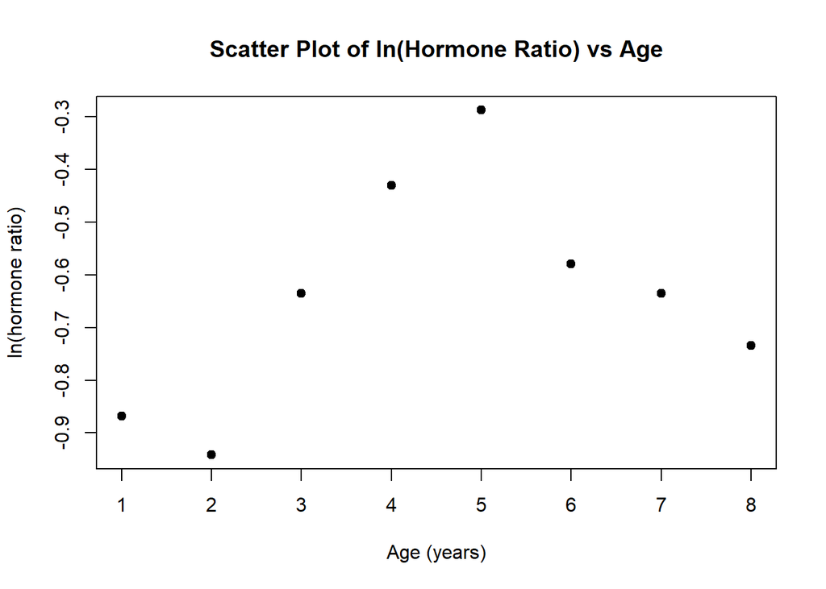

```r
# 输入原始数据
Age <- c(1, 2, 3, 4, 5,
         6, 7, 8)
Hormone_Ratio <- c(0.42, 0.39, 0.53, 0.65, 0.75,
                   0.56, 0.53, 0.48)

# 计算自然对数 ln(hormone ratio)
# 注意：R 中的 log() 默认即为自然对数
ln_ratio <- log(Hormone_Ratio)

# 构建数据框
panther_data <- data.frame(Age, Hormone_Ratio, ln_ratio)

# 绘制散点图
plot(panther_data$Age, panther_data$ln_ratio,
     main = "Scatter Plot of ln(Hormone Ratio) vs Age",
     xlab = "Age (years)", ylab = "ln(hormone ratio)",
     pch = 19, col = "black")
```

**结论解析**： 观察散点图的数据分布，这 8 个点并没有呈现出单调递增或递减的直线趋势，而是近似表现出**倒 U 型（抛物线）轨迹**——对数激素比值在 5 岁左右达到顶峰，随后开始下降。因此，两个变量之间的关系呈现出非线性特征。

## 4.2 拟合简单线性回归模型

这里强行用一条直线去拟合这种非线性数据，并检验其预测效果。

```r
# 拟合线性模型（Y = β0 + β1*X + ε）
model_linear <- lm(ln_ratio ~ Age, data = panther_data)
summary(model_linear)
```

```
Call:
lm(formula = ln_ratio ~ Age, data = panther_data)

Residuals:
     Min       1Q   Median       3Q      Max
-0.22008 -0.13738 -0.03457  0.09635  0.33468

Coefficients:
            Estimate Std. Error t value Pr(>|t|)
(Intercept) -0.78764    0.16749  -4.703  0.00332 **
Age          0.03306    0.03317   0.997  0.35743
---
Signif. codes:  0 '***' 0.001 '**' 0.01 '*' 0.05 '.' 0.1 ' ' 1

Residual standard error: 0.215 on 6 degrees of freedom
Multiple R-squared:  0.142, Adjusted R-squared:  -0.0009683
F-statistic: 0.9932 on 1 and 6 DF,  p-value: 0.3574
```

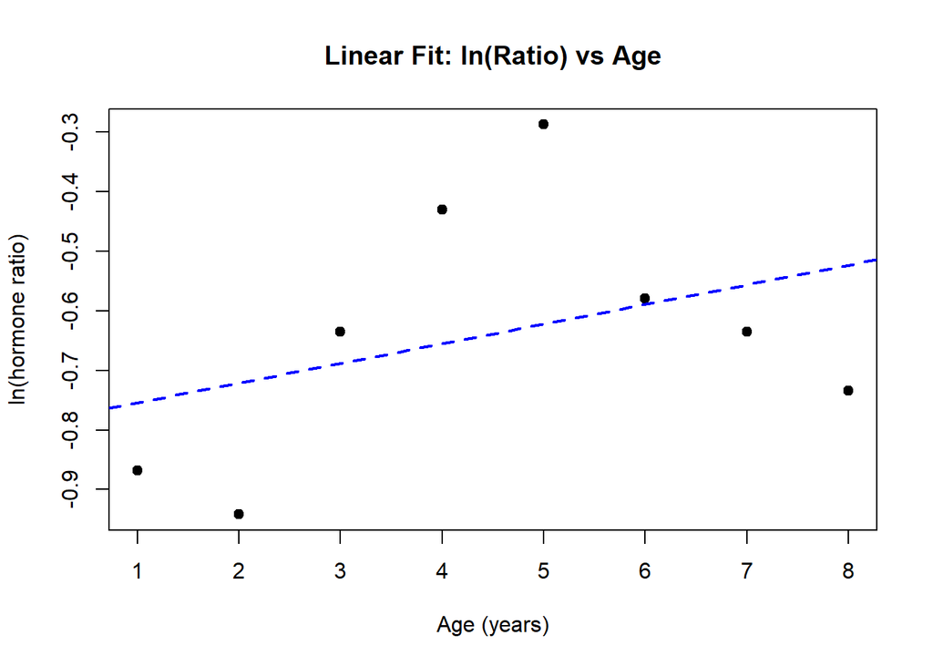

```r
# 在原散点图上添加最小二乘拟合直线
plot(panther_data$Age, panther_data$ln_ratio,
     main = "Linear Fit: ln(Ratio) vs Age",
     xlab = "Age (years)", ylab = "ln(hormone ratio)",
     pch = 19, col = "black")
abline(model_linear, col = "blue", lwd = 2, lty = 2) # 添加拟合直线，蓝色虚线
```

**统计推断**： 预测变量 `Age` 的 p-value 为 0.3574338，大于 0.05。

- **结论**：在 $\alpha = 0.05$ 的显著性水平下，该线性模型**不能**显著预测激素比值。
- **原因**：由于数据的非线性特征，线性模型无法捕捉到激素比值随年龄变化的真实模式，因此拟合效果较差，导致预测变量的 p-value 不显著。

## 4.3 添加二次项并进行嵌套模型比较（ANOVA）

为了拟合倒 U 型趋势，我们在模型中引入 `Age` 的平方项，构建二次多项式回归模型。 在 R 的 `lm()` 公式中，由于 `^` 符号有特殊含义，必须使用 `I(Age^2)` 函数将其作为纯数学运算进行绝缘处理。

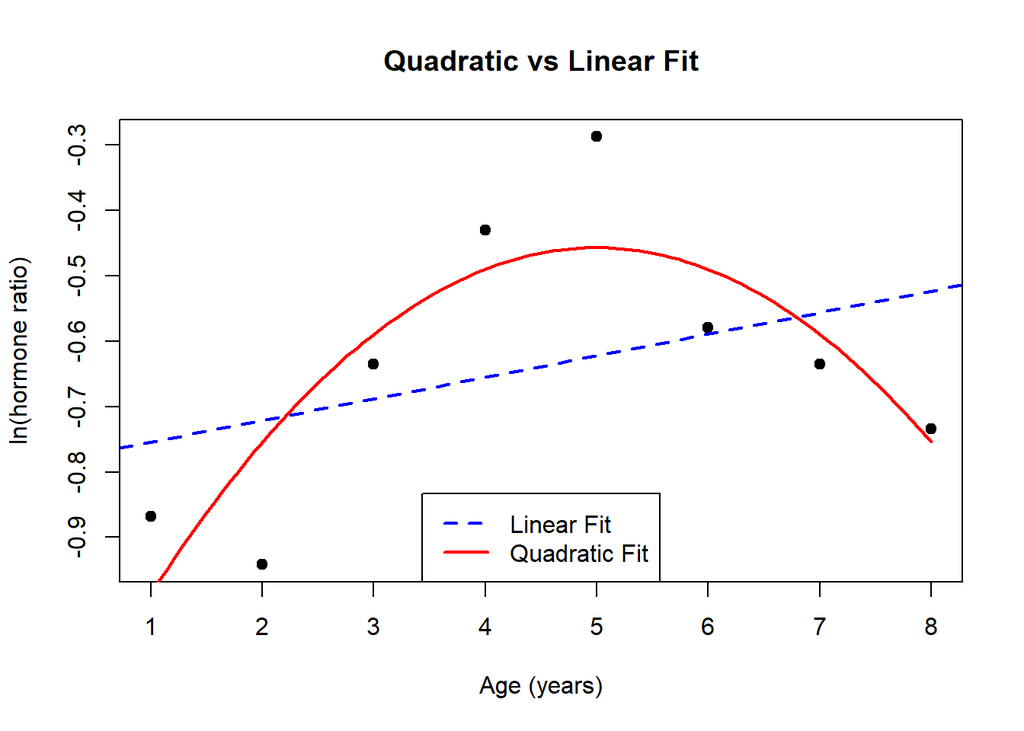

```r
# 拟合二次多项式模型（Y = β0 + β1*X + β2*X^2 + ε）
model_quad <- lm(ln_ratio ~ Age + I(Age^2), data = panther_data)

# 重新绘制散点图
plot(panther_data$Age, panther_data$ln_ratio,
     main = "Quadratic vs Linear Fit",
     xlab = "Age (years)", ylab = "ln(hormone ratio)", # 注意：这里的 x 轴标签仍然是 Age
     pch = 19, col = "black")

# 绘制二次拟合曲线
# 生成连续的 X 值以保证曲线平滑
# predict() 函数会根据模型参数计算出对应的 Y 值（ln_ratio），从而绘制出拟合曲线
age_seq <- seq(min(panther_data$Age), max(panther_data$Age), length.out = 100) # 从最小年龄到最大年龄生成 100 个点
quad_pred <- predict(model_quad, newdata = data.frame(Age = age_seq)) # 预测每个年龄（100 个点）的 ln_ratio

abline(model_linear, col = "blue", lwd = 2, lty = 2) # 添加线性拟合直线，蓝色虚线
lines(age_seq, quad_pred, col = "red", lwd = 2) # 添加二次拟合曲线，红色实线

# 添加图例
legend("bottom", legend = c("Linear Fit", "Quadratic Fit"),
       col = c("blue", "red"), lwd = 2, lty = c(2, 1))
```

```r
# 使用 ANOVA 比较两个模型
anova_res <- anova(model_linear, model_quad)
print(anova_res)
```

```
Analysis of Variance Table

Model 1: ln_ratio ~ Age
Model 2: ln_ratio ~ Age + I(Age^2)
  Res.Df      RSS Df Sum of Sq      F  Pr(>F)
1      6 0.277227
2      5 0.093855  1   0.18337 9.7689 0.02609 *
---
Signif. codes:  0 '***' 0.001 '**' 0.01 '*' 0.05 '.' 0.1 ' ' 1
```

```r
# 预先提取 ANOVA 表中的 p 值，避免在行内 R 代码中出现特殊字符导致解析错误
anova_pval <- anova_res$`Pr(>F)`[2]
```

**统计推断与 ANOVA 原理**：

- **ANOVA 的作用**：这里的 `anova()` 用于比较两个**嵌套模型**。它检验的 $H_0$ 是：复杂模型（加入二次项）相比于简单模型（仅有一次项），其残差平方和（RSS）的减少量仅仅是随机误差导致的。
- **结果分析**：观察 `anova()` 输出表中的 `Pr(>F)` 值为 0.0260889，$< 0.05$，说明增加 `Age^2` 项显著降低了模型的预测误差。
- **最终结论**：增加 `Age^2` 项显著改善了对雄性豹激素水平的预测（p 值显著）。这进一步验证了激素比值与年龄之间的关系是非线性的，且二次项的引入成功捕捉到了数据中的倒 U 型趋势。

# 5 Question 5

## 5.1 拟合完整的多元逻辑回归模型

题目明确指出，必须将 `race`、`smoke` 和 `ht` 这些本质上是分类变量但被存储为整数的数据转换为因子（factor）类型。这对逻辑回归极其重要，否则 R 会把它们当成连续的数值变量来计算斜率，从而得出毫无意义的结果。

```r
# 加载必要的包和数据
library(MASS)
data(birthwt)

# 将指定变量转换为分类因子（Factors）
birthwt$race <- as.factor(birthwt$race)
birthwt$smoke <- as.factor(birthwt$smoke)
birthwt$ht <- as.factor(birthwt$ht)

# 确保因变量低体重（low）也是二元形式的，可以直接用于 glm()
```

在 R 中拟合逻辑回归，我们使用 `glm()` 函数，且必须将 `family` 参数设置为 `binomial`（二项分布）（原因是响应变量 `low` 是二元的）。

```r
# 拟合包含所有指定预测变量的模型（Model A）
model_a <- glm(low ~ age + lwt + race + smoke + ht,
               data = birthwt,
               family = binomial)
summary(model_a)
```

```
Call:
glm(formula = low ~ age + lwt + race + smoke + ht, family = binomial,
    data = birthwt)

Coefficients:
             Estimate Std. Error z value Pr(>|z|)
(Intercept)  0.777274   1.160336   0.670  0.50294
age         -0.021166   0.034960  -0.605  0.54489
lwt         -0.017297   0.006866  -2.519  0.01176 *
race2        1.238728   0.526253   2.354  0.01858 *
race3        0.919052   0.427195   2.151  0.03145 *
smoke1       1.064664   0.389159   2.736  0.00622 **
ht1          1.732974   0.687931   2.519  0.01177 *
---
Signif. codes:  0 '***' 0.001 '**' 0.01 '*' 0.05 '.' 0.1 ' ' 1

(Dispersion parameter for binomial family taken to be 1)

    Null deviance: 234.67  on 188  degrees of freedom
Residual deviance: 207.88  on 182  degrees of freedom
AIC: 221.88

Number of Fisher Scoring iterations: 4
```

**大致结果分析**：

- `age` 的 p-value 大于 0.05，表明在控制了其他变量后，母亲年龄对新生儿低体重的影响不显著。
- 其他变量（`lwt`, `race2`, `race3`, `smoke1`, `ht1`）的 p-value 都小于 0.05，表明它们在统计学上显著影响低体重的发生。

## 5.2 特征降维与构建简化模型

题目要求剔除在模型（a）中不显著的特征（$p \ge 0.05$），保留显著的特征重新构建模型。根据分析结果，剔除 `age`，保留 `lwt`、`race`、`smoke` 和 `ht`。

```r
# 构建简化后的回归模型（Model B）
# 保留显著特征：lwt, race, smoke, ht
model_b <- glm(low ~ lwt + race + smoke + ht,
               data = birthwt,
               family = binomial)
summary(model_b)
```

```
Call:
glm(formula = low ~ lwt + race + smoke + ht, family = binomial,
    data = birthwt)

Coefficients:
             Estimate Std. Error z value Pr(>|z|)
(Intercept)  0.352049   0.924438   0.381  0.70333
lwt         -0.017907   0.006799  -2.634  0.00844 **
race2        1.287662   0.521648   2.468  0.01357 *
race3        0.943645   0.423382   2.229  0.02583 *
smoke1       1.071566   0.387517   2.765  0.00569 **
ht1          1.749163   0.690820   2.532  0.01134 *
---
Signif. codes:  0 '***' 0.001 '**' 0.01 '*' 0.05 '.' 0.1 ' ' 1

(Dispersion parameter for binomial family taken to be 1)

    Null deviance: 234.67  on 188  degrees of freedom
Residual deviance: 208.25  on 183  degrees of freedom
AIC: 220.25

Number of Fisher Scoring iterations: 4
```

## 5.3 模型比较：似然比检验（Likelihood Ratio Test）

剔除一些变量得到了一个更简单的“嵌套模型”后，我们需要证明：**这种简化是否导致了模型预测能力的显著下降？** 对于逻辑回归（GLM），我们不能使用普通的 ANOVA 中的 F 检验，而必须使用基于卡方分布的**似然比检验**。

```r
# 使用卡方检验比较两个嵌套模型
model_diff_test <- anova(model_b, model_a, test = "Chisq")
print(model_diff_test)
```

```
Analysis of Deviance Table

Model 1: low ~ lwt + race + smoke + ht
Model 2: low ~ age + lwt + race + smoke + ht
  Resid. Df Resid. Dev Df Deviance Pr(>Chi)
1       183     208.25
2       182     207.88  1   0.3699   0.5431
```

```r
# 提取 p-value
p_value_diff <- model_diff_test$`Pr(>Chi)`[2]
```

**结论**： P-value 为 0.5431，大于 0.05，说明剔除 `age` 后模型的预测能力没有显著下降。因此，简化后的模型（Model B）在统计学上是合理的。

## 5.4 机器学习初步：训练集与测试集划分

这里引入监督学习中最核心的范式：不要在用来训练模型的数据上测试模型的准确率（这会导致过拟合评估）。我们随机抽取 100 个样本作为训练集（Training set），剩下的 89 个作为测试集（Test set）。

```r
# 1. 设置随机种子，保证每次抽样的结果完全一致
set.seed(320) # 此处疑似暗示 320 大院（笑）

# 2. 生成训练集的索引（从总行数中随机抽取 100 个数字）
train_indices <- sample(1:nrow(birthwt), 100, replace = FALSE) # replace = FALSE（默认）表示不放回抽样

# 3. 划分训练集和测试集
train_data <- birthwt[train_indices, ]
test_data <- birthwt[-train_indices, ] # 负号代表排除这些行

# 4. 使用训练集重新拟合模型（a）
model_train <- glm(low ~ age + lwt + race + smoke + ht,
                   data = train_data,
                   family = binomial)

# 5. 对测试集进行预测
# 这一步的意思是：使用训练好的模型 `model_train` 来预测测试集 `test_data` 中每个样本的低体重发生概率（而不是直接预测类别）
# 注意：type = "response" 告诉 R 输出介于 0 到 1 之间的发生概率，而不是对数几率（logit）
predicted_probs <- predict(model_train, newdata = test_data, type = "response")

# 6. 将概率转换为分类结果（阈值为 0.5）
predicted_class <- ifelse(predicted_probs >= 0.5, 1, 0)

# 7. 计算准确率
# 将预测类别与测试集的真实类别 (test_data$low) 进行对比
correct_predictions <- sum(predicted_class == test_data$low) # 计算正确预测的数量
total_predictions <- nrow(test_data) # 计算测试集的总样本数
accuracy <- correct_predictions / total_predictions

# 打印结果
cat("模型在独立测试集上的预测准确率为:", round(accuracy * 100, 2), "%\n")
```

```
模型在独立测试集上的预测准确率为: 69.66 %
```

```r
# 输出混淆矩阵以提供更多细节
# 混淆矩阵（Confusion Matrix）：行表示预测类别，列表示实际类别
table(Predicted = predicted_class, Actual = test_data$low)
```

```
         Actual
Predicted  0  1
        0 56 24
        1  3  6
```